# COUNTLAND: R tutorial

### Samuel H. Church

This tutorial demonstrates the major functions of `countland` by applying them to a Gold standard single-cell RNA sequencing dataset from Freytag *et al* (2018).

`countland` is a **barebones** set of functions for applying a restricted linear algebra to the analysis of count-based data. As such, there are many opportunities for further optimization that may prove useful in the anlaysis of your own data. We provide the source code freely available at https://github.com/shchurch/countland and encourage users and developers to fork the code for their own purposes.

The following packages are required to complete the tutorial

```r
library(Seurat)
```

```r
library(ggplot2)
theme_set(theme_classic())
```

## GET THE DATA

We have used the Gold standard dataset provided by Freytag *et al* (2018). This data consists of ~1000 cells that have ground truth labels corresponding to three human lung cell lines.

`countland` accepts an sparse data matrix (as does `Seurat`).

```r
gold.data <- Seurat::Read10X(data.dir = "../data/Gold_Freytag2018/")
m <- gold.data
```

## IMPORT COUNTLAND

The source code for `countland` in `R` is located in `countland-R/R/`

```r
source("R/countland.R")
source("R/countland_cluster.R")
source("R/countland_rank_reduction.R")
source("R/countland_genes.R")
source("R/countland_utils.R")
```

## INITIALIZE COUNTLAND OBJECT

Initialize `countland` by calling the core function on sparse data matrix.

```r
C <- countland(m)
```

```
## [1] "countland object"
## [1] "after removing empty cells and genes,"
## [1] "the count matrix has 29212 genes (rows)"
## [1] "    and 925 cells (columns)"
## [1] "the fraction of entries that are nonzero is 0.2905"
```

The count matrix is stored in `C@counts`

```r
C@counts[1:10,1:10]
```

```
## 10 x 10 sparse Matrix of class "dgCMatrix"
```

```
##    [[ suppressing 10 column names 'H2228_AAACCTGCAGACACTT-1', 'H1975_AAAGATGCACATTTCT-1', 'H1975_AAAGATGTCCTTTACA-1' ... ]]
```

```
##
## ENSG00000243485 . . . . . . . . . .
## ENSG00000238009 . . . . . . . . . .
## ENSG00000239945 . . . . . . . . . .
## ENSG00000233750 . . . . . . . . . .
## ENSG00000268903 . . . . . . . . . .
## ENSG00000241860 . . . . . . . 1 . .
## ENSG00000279457 . . . . . . . . . .
## ENSG00000228463 . . . . . 1 . . . .
## ENSG00000236601 . . . . . . . . . .
## ENSG00000237094 . . . . . 2 . . . .
```

Note that most counts are zero for scRNA-seq data.

## EVALUATE DATA QUALITY

We can establish data quality by checking the total number of counts and other expression measures per cell.

In addition, it can be helpful to see how many counts are derived from certain genes, such as mitochondrial genes (here we have chosen a gene name with particularly high counts, regular expressions are permitted for name matching).

Expression measures include: - maximum number of counts observed across genes - total counts - number of genes with observed counts - number of genes with counts above 1, or 10 - number of unique count values per cell - count index = number of *n* genes with *n* counts

```r
# flag genes starting with MT (mitchondrial genes)
gene_string <- "^ENSG00000140988$"
C <- ScoreCells(C,gene_string)
head(C@cell_scores)
```

```
##                      names n_features max_count_value total_counts
## 1 H1975_AAAGATGCACATTTCT-1       8574            1010       100763
## 2 H1975_AAAGATGTCCTTTACA-1       9190            1803       121201
## 3 H1975_AAATGCCCACTTCGAA-1       8433            1097        95220
## 4 H1975_AAATGCCTCATATCGG-1       8311            1678        99321
## 5 H1975_AACACGTGTCAGAAGC-1       8642            1142       106598
## 6 H1975_AACCATGAGCGTAGTG-1       7907            1549        90917
##   n_features_above1 n_features_above10 unique_count_values count_index
## 1              5746               1432                 227          25
## 2              6316               1567                 245          24
## 3              5643               1390                 219          24
## 4              5556               1247                 221          25
## 5              5833               1431                 231          24
## 6              5058               1127                 214          23
##   feature_match_counts
## 1                  919
## 2                 1605
## 3                 1097
## 4                 1433
## 5                 1141
## 6                 1002
```

## FILTER DATA

Standard workflows often filter data based on quality measures, such as the number of unique features per cell.

```r
filter_cell_names <- C@cell_scores[C@cell_scores$n_features < 8500,]$names
filter_cell_index <- which(C@names_cells %in% filter_cell_names) # cells with fewer than 8,500 unique features
C <- SubsetCells(C,filter_cell_index,remove_empty=FALSE)
```

```
## [1] "new number of genes: 29212"
## [1] "new number of cells: 463"
```

```r
# row positions (i) represent observations of a gene
obsgenes <- unique(C@counts@i)
# sort and index starting at 1 rather than 0
obsgenes <- sort(obsgenes+1)
C <- SubsetGenes(C,obsgenes) # genes with observations
```

```
## [1] "after subsetting and removing empty cells and genes,"
## [1] "after removing empty cells and genes,"
## [1] "new number of genes: 26298"
## [1] "new number of cells: 463"
```

```r
# note the same could be accomplished by running
#     C <- SubsetCells(C,filter_cells,remove_empty=TRUE)
# above
```

With `countland`, such data filtering may not be necessary or helpful. The original count matrix can be restored at any time.

```r
C <- RestoreCounts(C)
```

```
## [1] "new number of genes: 29212"
## [1] "new number of cells: 925"
```

## SUBSAMPLE GENES

Cells are not sequenced to standard sequencing depth. This is sometimes a problem for downstream comparisons.

You can create an alternative count matrix where cells have an equal number of counts using `Subsample()`. The number of counts must not be larger than the minimum number per cell.

This matrix is stored in `C@subsample`

```r
set.seed(84095)
C <- Subsample(C,n_counts=1000)
```

## COMPARE GENES BY COUNTS

Using the subsampled count matrix, we can make comparisons of gene expression using several count-based assessments. These include:

- maximum number of counts observed across cells
- total counts
- number of cells with observed counts
- number of cells with counts above 1, or 10
- number of unique count values
- count index = number of *n* cells with *n* counts

```r
C <- ScoreGenes(C)
head(C@gene_scores)
```

```
##             names n_cells max_count_value total_counts n_cells_above1
## 1 ENSG00000000003      25               2           26              1
## 2 ENSG00000000419      84               2           86              2
## 3 ENSG00000000457       2               1            2              0
## 4 ENSG00000000460       9               1            9              0
## 5 ENSG00000000938       0               0            0              0
## 6 ENSG00000000971       8               1            8              0
##   n_cells_above10 unique_count_values count_index
## 1               0                   2           1
## 2               0                   2           2
## 3               0                   1           1
## 4               0                   1           1
## 5               0                   0           0
## 6               0                   1           1
```

We can also visualize counts across genes with a stripplot

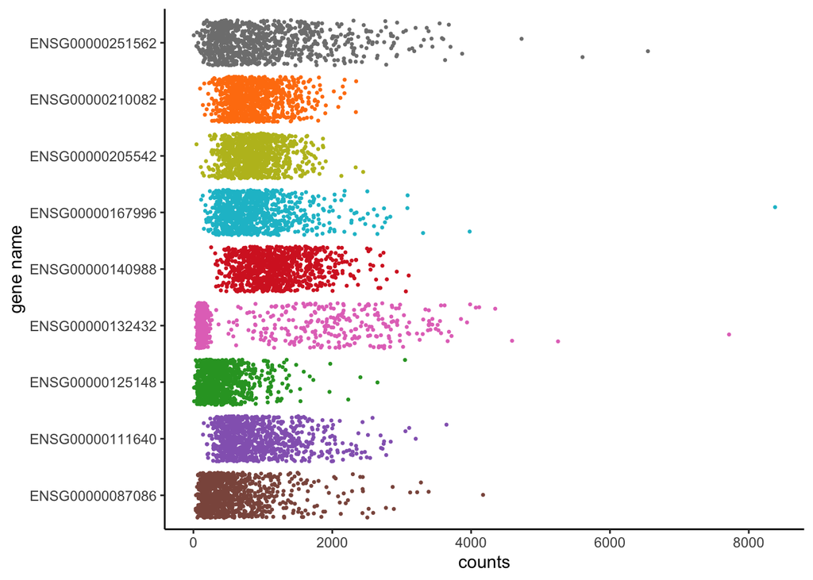

```r
top_genes <- which(C@names_genes %in% head(C@gene_scores[order(-C@gene_scores$unique_count_values),],9)$names)
PlotGeneCounts(C,top_genes)
```

## COMPARE CELLS AND CLUSTER

The dot (or inner) product is a measure of alignment between vectors. In this case, it tells us how similar two cells are based on the proportions of counts, and scaled by the total counts per cell. A dot product of 0 indicates orthogonal cell vectors (no shared counts), larger values indicate aligned cell vectors.

```r
C <- Dot(C)
```

```
## [1] "Calculating dot products between rows..."
## [1] "    done."
```

Cell populations can be compared and distinguished by embedding and clustering the matrix of pairwise dot products (contained in `C.dots`). This matrix is an unbounded affinity matrix. It is symmetric, and contains only integer values above 0. Spectral embedding clustering is appropriate for this type of matrix.

First, we embed to investigate the optimal number of clusters for our data.

```r
C <- Embed(C)
```

```
## [1] "Performing spectral embedding on dot products..."
## [1] "    done."
```

The eigengap heuristic is can help decide the optimal number of clusters, but it is only a guideline. According to this heuristic, the optimal number of clusters is *k* where the difference in eigenvalues $ | e_{k+1} - e_{k} | $ is largest.

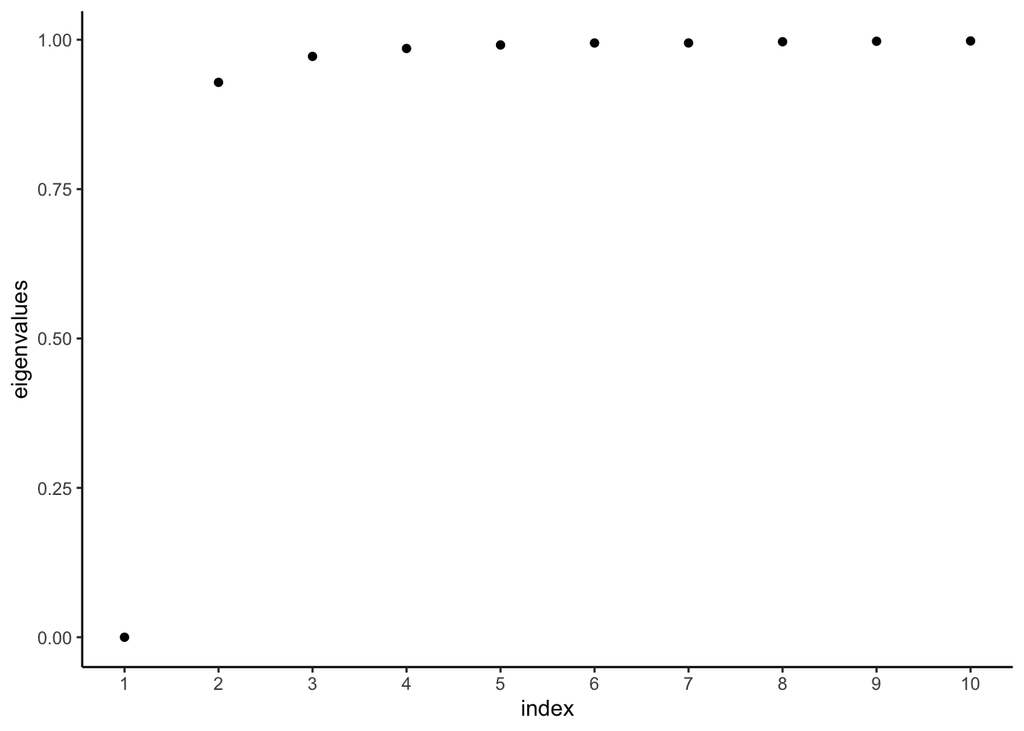

```r
PlotEigengap(C)
```

For many datasets, you may want to consider other factors, e.g. choosing a minimum number of clusters, whether or not the eigengap reflects this.

Here we have chosen 3 as the optimal number of clusters.

```r
C <- Cluster(C,n_clusters=3)
```

```
## [1] "Performing spectral clustering on dot products..."
## [1] 3
## [1] "    done."
```

### VISUALIZING WITH SPECTRAL EMBEDDING OF DOT PRODUCTS

We can now visualize clusters using spectral embedding.

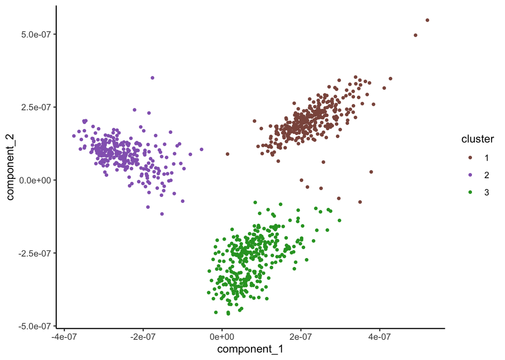

```r
PlotEmbedding(C)
```

## IDENTIFY MARKER GENES

What makes a gene an ideal marker for a cluster may depend on downstream applications. For example, the ideal marker gene might be defined as the gene detected in all of the cells in a given cluster and none of the rest.

Under this definition, the top marker gene for each cluster can be identified by counting and comparing the number of non-zero cells.

```r
C <- RankMarkerGenes(C,method='prop-zero')
C@marker_genes[(C@marker_genes$cluster_label == 1),]
```

```
##                           names gene_index diff.zeros rank cluster_label
## ENSG00000182636 ENSG00000182636      20835  0.9096367    1             1
## ENSG00000100234 ENSG00000100234      28462  0.9013585    2             1
## ENSG00000169083 ENSG00000169083      12264  0.8970879    3             1
## ENSG00000229391 ENSG00000229391       9428  0.8951280    4             1
## ENSG00000120675 ENSG00000120675      19481  0.8909451    5             1
## ENSG00000149557 ENSG00000149557      16458  0.8895731    6             1
## ENSG00000121858 ENSG00000121858       6136  0.8875255    7             1
## ENSG00000158089 ENSG00000158089       3113  0.8838429    8             1
## ENSG00000214548 ENSG00000214548      20690  0.8787677    9             1
## ENSG00000179344 ENSG00000179344       9431  0.8718409   10             1
```

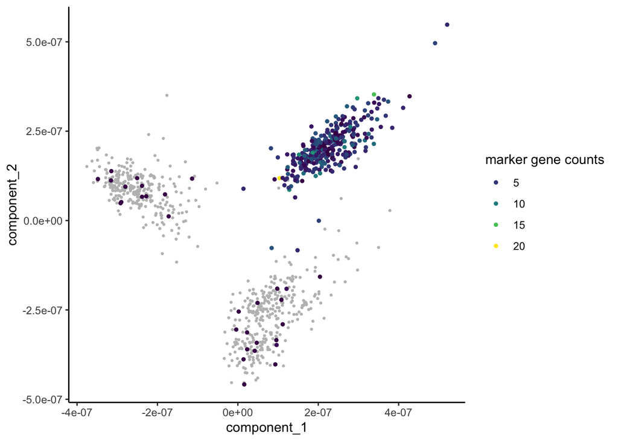

```r
cluster_marker <- C@marker_genes[C@marker_genes$cluster_label == 1,]
cluster_top <- cluster_marker[cluster_marker$rank == 1,]$names
gene_index = which(C@names_genes == cluster_top)
PlotMarker(C,gene_index)
```

Alternatively, the top marker genes for each cluster can be identified by ranking genes using the Wilcoxon rank-sum statistic.

```r
C <- RankMarkerGenes(C,method='rank-sums')
C@marker_genes[(C@marker_genes$cluster_label == 1),]
```

```
##                 names gene_index statistic        pvalue    adj.pvalue
## 20835 ENSG00000182636      20835  189293.5 3.654371e-168 1.067515e-163
## 28462 ENSG00000100234      28462  189212.5 2.219628e-166 3.241988e-162
## 9431  ENSG00000179344       9431  191888.0 3.434679e-166 3.344462e-162
## 16458 ENSG00000149557      16458  189799.5 9.276423e-166 6.774572e-162
## 9428  ENSG00000229391       9428  188813.5 1.781360e-165 1.040742e-161
## 6136  ENSG00000121858       6136  190094.0 5.479660e-165 2.667864e-161
## 12264 ENSG00000169083      12264  185820.0 9.158836e-164 3.822113e-160
## 13164 ENSG00000131203      13164  190338.0 7.731547e-162 2.823174e-158
## 20690 ENSG00000214548      20690  188131.0 3.413473e-161 1.107937e-157
## 19481 ENSG00000120675      19481  186754.0 8.958496e-161 2.616956e-157
##       significant rank cluster_label
## 20835        TRUE    1             1
## 28462        TRUE    2             1
## 9431         TRUE    3             1
## 16458        TRUE    4             1
## 9428         TRUE    5             1
## 6136         TRUE    6             1
## 12264        TRUE    7             1
## 13164        TRUE    8             1
## 20690        TRUE    9             1
## 19481        TRUE   10             1
```

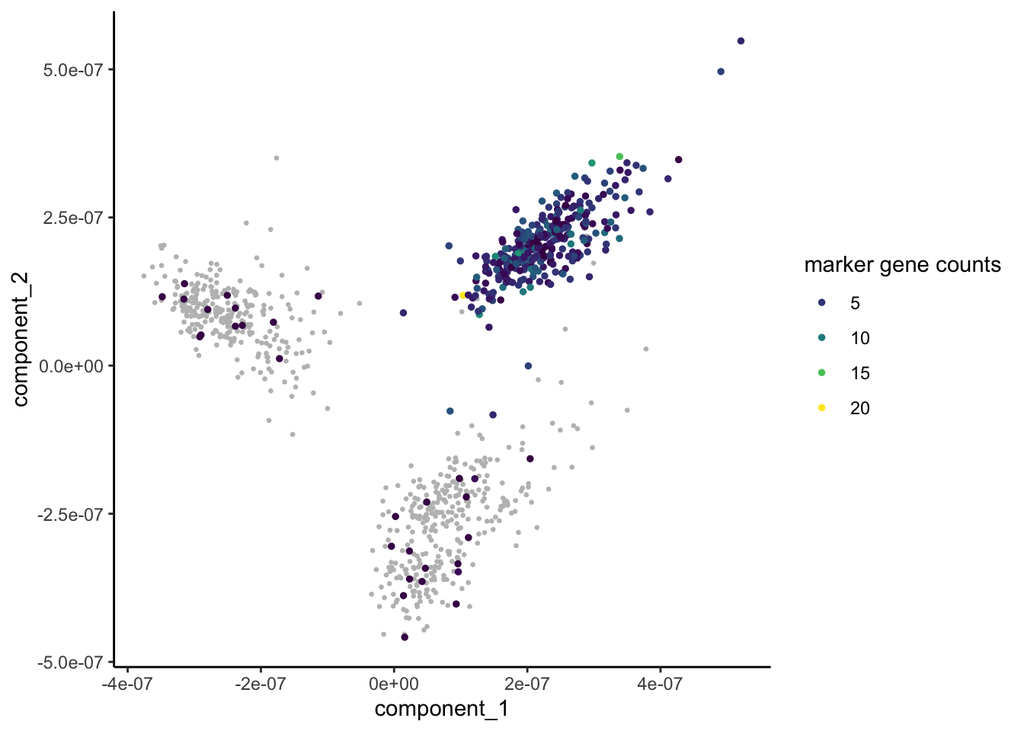

```r
cluster_marker <- C@marker_genes[C@marker_genes$cluster_label == 1,]
cluster_top <- cluster_marker[cluster_marker$rank == 1,]$names
gene_index = which(C@names_genes == cluster_top)
PlotMarker(C,gene_index)
```

## OTHER VISUALIZATIONS

### UMAP OF RAW COUNTS

Alternative to spectral embedding and clustering, we can borrow a page from standard workflows and implement a uniform manifold approximation and projection (UMAP) for dimensional reduction in `countland`. Here this is applied to raw, rather than transformed counts. These can be either subsampled to standard number of counts across cells or the standard count matrix.

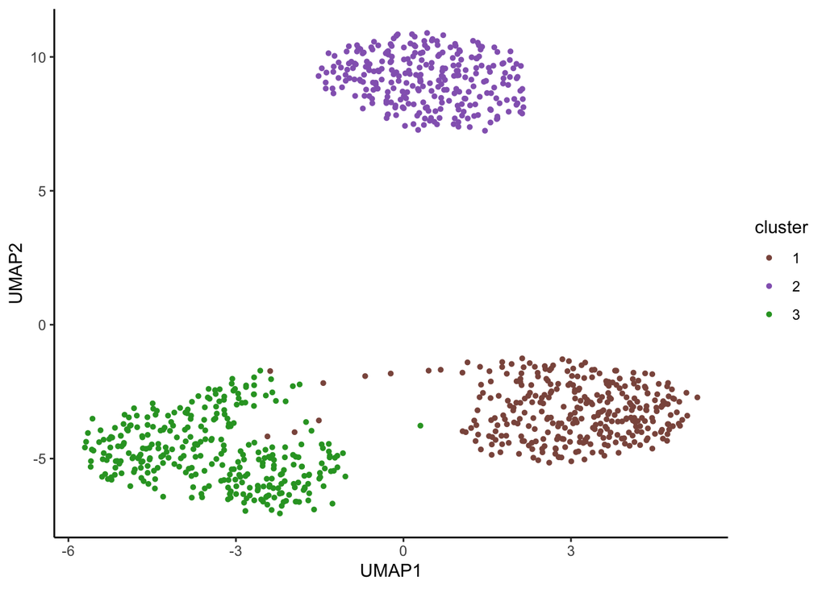

```r
PlotUMAP(C,subsample=TRUE)
```

### GLM-PCA

An alternative approach for comparing cells using untransformed counts is generalized linear model based PCA, or GLM-PCA. This has been described for scRNA-seq data [here](https://doi.org/10.1186/s13059-019-1861-6) and implemented [here](https://github.com/willtownes/glmpca-py).

**Note this can take some time.**

```r
#install.packages("glmpca")
library(glmpca)
res <- glmpca(as(C@counts,"matrix"),2)
```

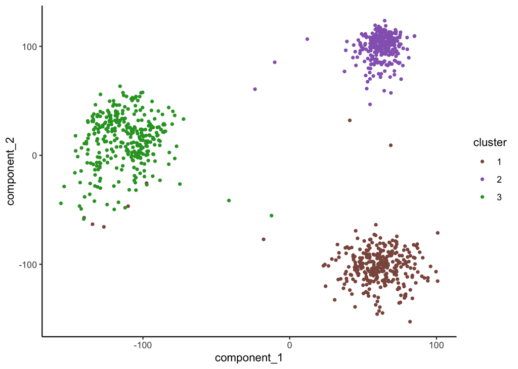

```r
factors <- res$factors
glmpca_df <- data.frame("component_1" = factors[,1],"component_2"=factors[,2],"cluster"=C@cluster_labels)
    ggplot(glmpca_df,aes(x = component_1,y = component_2, color=as.character(cluster))) +
  geom_point(size=1) +
  guides(color=guide_legend(title="cluster")) +
  scale_color_manual(values=color_palette)
```